# Coursera Machine Learning - Project

Bernard Fraenkel

September 25, 2015

# Synopsis

The goal of this project is to determine *how well* participants in various training exercises perform these exercises data from accelerometers on the belt, forearm, arm, and dumbell of 6 participants. They were asked to perform barbell lifts correctly and incorrectly in 5 different ways. More information is available from [this website](http://groupware.les.inf.puc-rio.br/har) (see the section on the Weight Lifting Exercise Dataset).

The report below shows are a model is created using the [gbm](https://cran.r-project.org/web/packages/gbm/gbm.pdf) package using the training set, and computes the predictions on a 20-sample test set.

# Data

The training data for this project are available here: https://d396qusza40orc.cloudfront.net/predmachlearn/pml-training.csv

The test data are available here: https://d396qusza40orc.cloudfront.net/predmachlearn/pml-testing.csv

## Loading libraries and data

- Load libraries

```r
library(ggplot2)
library(gridExtra)
library(plyr) # Has to be before dplyr
library(dplyr)
library(reshape2)
library(caret)
```

- Load the training and testing data sets

```r
training <- read.csv("pml-training.csv")
testing <- read.csv("pml-testing.csv")
```

## Pre-processing

We apply the following pre-processing steps to the data:

```r
# Remove rows that have NA
training_na <- training[complete.cases(training),]

# A lot of columns in testing data set are 100% NA
# -> remove them from both training and testing
nb_test <- nrow(testing)
all_na <-  which(apply(testing, 2, function(x) sum(is.na(x))==nb_test))
testing2 <- testing[,-all_na]
training2 <- training[,-all_na]

# also remove the first column which is just an index
testing2 <- testing2[,-1]
training2 <- training2[,-1]

# eliminate columns with factors with only 1 level
# in either training or testing
to_rm = c()
# Exclude the last column which is different for train & test
for (colmn in colnames(training2[,-ncol(training2)])) {
    if (class(training2[,colmn]) == "factor") {
        if ((nlevels(testing2[,colmn]) < 2) | (nlevels(training2[,colmn]) < 2)) {
            col_nb <- grep(colmn,colnames(testing2)) # convert to column index
            to_rm <- c(to_rm, col_nb) # add to list of "to remove"
        }
    }
}
training2 <- training2[,-to_rm]
testing2 <- testing2[,-to_rm]
```

# Model Definition

We use a generalized boosted tree regression model as implemented in the [gbm](https://cran.r-project.org/web/packages/gbm/gbm.pdf) package.

```r
fitControl <- trainControl(method = "repeatedcv", number = 10, repeats = 1)
set.seed(4053)
gbmFit <- train(classe ~ ., data = training2, method = "gbm",
                 trControl = fitControl, verbose = FALSE)
```

The variables driving the clustering are displayed below

```r
varImp(gbmFit)
```

```
## gbm variable importance
##
##   only 20 most important variables shown (out of 79)
##
##                                Overall
## raw_timestamp_part_1           100.000
## roll_belt                       57.470
## num_window                      28.890
## pitch_forearm                   24.673
## roll_forearm                    17.799
## magnet_dumbbell_z               16.851
## cvtd_timestamp28/11/2011 14:15  12.647
## cvtd_timestamp30/11/2011 17:12  12.285
## magnet_dumbbell_y               12.183
## pitch_belt                      10.059
## cvtd_timestamp02/12/2011 13:33   7.545
## roll_dumbbell                    6.558
## yaw_belt                         6.393
## accel_forearm_x                  5.769
## cvtd_timestamp02/12/2011 13:34   5.644
## magnet_belt_z                    5.568
## cvtd_timestamp02/12/2011 14:58   5.565
## gyros_dumbbell_y                 5.456
## gyros_belt_z                     4.747
## accel_dumbbell_y                 4.591
```

# Cross validation and Expected out of sample error

We are using k-fold cross validation with **K = 10**

The expected out-of-sample error is given by the **Accuracy** or **Kapa** metrics below

```r
gbmFit
```

```
## Stochastic Gradient Boosting
##
## 19622 samples
##    57 predictor
##     5 classes: 'A', 'B', 'C', 'D', 'E'
##
## No pre-processing
## Resampling: Cross-Validated (10 fold, repeated 1 times)
## Summary of sample sizes: 17660, 17660, 17659, 17660, 17660, 17660, ...
## Resampling results across tuning parameters:
##
##   interaction.depth  n.trees  Accuracy   Kappa      Accuracy SD
##   1                   50      0.8369175  0.7929828  0.006419459
##   1                  100      0.8993477  0.8725025  0.005850883
##   1                  150      0.9273262  0.9079327  0.005191108
##   2                   50      0.9565282  0.9449640  0.003182462
##   2                  100      0.9869535  0.9834959  0.003970626
##   2                  150      0.9918461  0.9896856  0.002821425
##   3                   50      0.9845578  0.9804668  0.003391741
##   3                  100      0.9940373  0.9924581  0.002366970
##   3                  150      0.9970441  0.9962613  0.001826629
##   Kappa SD
##   0.008108417
##   0.007416011
##   0.006580168
##   0.004031933
##   0.005026023
##   0.003569968
##   0.004291669
##   0.002994165
##   0.002310477
##
## Tuning parameter 'shrinkage' was held constant at a value of 0.1
##
## Tuning parameter 'n.minobsinnode' was held constant at a value of 10
## Accuracy was used to select the optimal model using  the largest value.
## The final values used for the model were n.trees = 150,
##  interaction.depth = 3, shrinkage = 0.1 and n.minobsinnode = 10.
```

The accuracy of the model through cross-validation is displayed below, parametrized by tree-depth

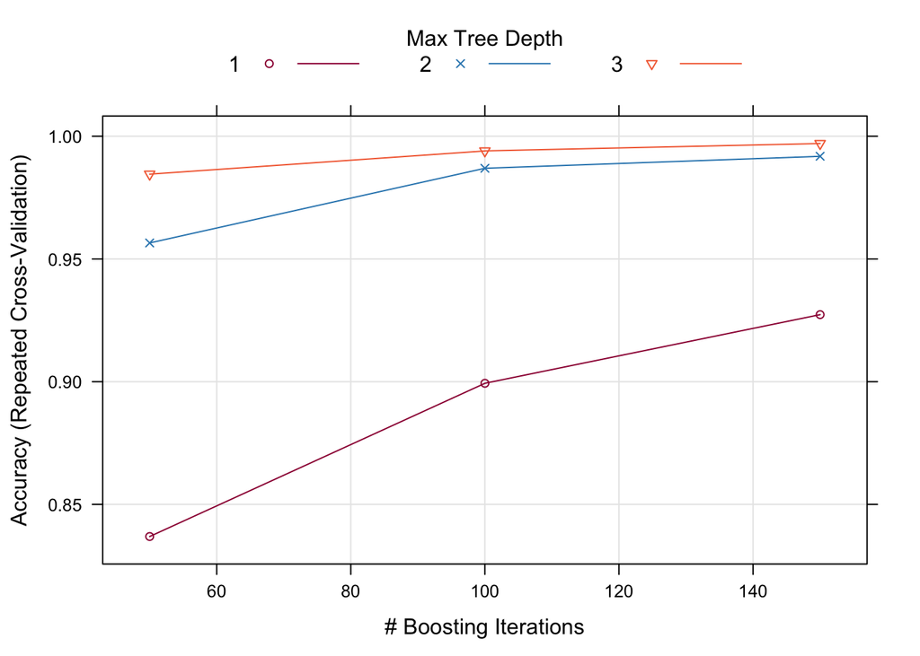

```r
trellis.par.set(caretTheme())
plot(gbmFit, metric = "Accuracy") # or Kappa - little difference
```

# Choices made

- The GBM model was selected because it is high performance and relatively fast. It is robust and does not require scaling/normalization, and can handle a large number of independent variables
- Previous experiments have shown that increasing the number of repeats does not improve the quality of the results, so we chose to only build the tree models 1. (Parameter *repeats = 1* in *trainControl*)

# Prediction on test cases

The prediction on the 20 test case samples are computed below

```r
results <- predict(gbmFit, newdata = testing)
results
```

```
##  [1] B A B A A E D B A A B C B A E E A B B B
## Levels: A B C D E
```

# Acknowledgment

We are thankful to [Human Activity Recognition](http://groupware.les.inf.puc-rio.br/har) for providing the data for this project